# 重賞レース予測レポート【レース終了】

作成日時: 2025/09/28 19:15:44

☞ [マニュアル(pdf)](https://ryutoro-galois.github.io/keiba-predictor/manual/manual.pdf)

☞ 過去5年の同一レース結果: [2024年](https://ryutoro-galois.github.io/keiba-predictor/report/PredResult_2024y_raceDate_20240928_20240929.html), [2023年](https://ryutoro-galois.github.io/keiba-predictor/report/PredResult_2023y_raceDate_20230930_20231001.html), [2022年](https://ryutoro-galois.github.io/keiba-predictor/report/PredResult_2022y_raceDate_20221001_20221002.html), [2021年](https://ryutoro-galois.github.io/keiba-predictor/report/PredResult_2021y_raceDate_20211002_20211003.html), [2020年](https://ryutoro-galois.github.io/keiba-predictor/report/PredResult_2020y_raceDate_20201003_20201004.html)

☞ 過去4週間の別レース結果: [1週前(9/20-21)](https://ryutoro-galois.github.io/keiba-predictor/report/PredResult_2025y_raceDate_20250920_20250921.html), [2週前(9/13-15)](https://ryutoro-galois.github.io/keiba-predictor/report/PredResult_2025y_raceDate_20250913_20250915.html), [3週前(9/6-7)](https://ryutoro-galois.github.io/keiba-predictor/report/PredResult_2025y_raceDate_20250906_20250907.html), [4週前(8/31)](https://ryutoro-galois.github.io/keiba-predictor/report/PredResult_2025y_raceDate_20250831_20250831.html)

☞ netkeiba: [シリウスステークス(GⅢ)](https://race.netkeiba.com/race/result.html?race_id=202509040811&rf=race_submenu), [スプリンターズステークス(GⅠ)](https://race.netkeiba.com/race/result.html?race_id=202506040911&rf=race_submenu)

☞ レース結果(csv): [9/27-28](https://ryutoro-galois.github.io/keiba-predictor/csv/race_result_20250927_20250928.csv)

## 【レース結果(1)】人気と着順の関係

### 【シリウスステークス(2025/09/27(土))】

【シリウスステークス(GⅢ)】  
2025/09/27(土), 09_阪神, ダ右2000m

[interactive chart not shown]

### 【スプリンターズステークス(2025/09/28(日))】

【スプリンターズステークス(GⅠ)】  
2025/09/28(日), 06_中山, 芝右外1200m

[interactive chart not shown]

## 【レース結果(2)】コーナー通過順位

### 【シリウスステークス(2025/09/27(土))】

【シリウスステークス(GⅢ)】  
2025/09/27(土), 09_阪神, ダ右2000m

[interactive chart not shown]

### 【スプリンターズステークス(2025/09/28(日))】

【スプリンターズステークス(GⅠ)】  
2025/09/28(日), 06_中山, 芝右外1200m

[interactive chart not shown]

## 0. 推し馬予測 (AI予測)

### 【シリウスステークス(GⅢ) 2025/09/27(土)】

- 本命(◎): 1-3着内確率(勝負強さ)が1位の馬
- 対抗(◯): 1-3着内確率が2-N位(20%程度以上)の中で予測タイムが最も速い馬
- 3番手(▲): 1-3着内確率が2-N位(20%程度以上)のでダークホース確率が最も高い馬
- 穴: ダークホース確率が上位1-M位(40%程度以上)の中で1-3着内確率が最も高い馬

| 推し馬 | 枠番 | 馬番 | 人気 | オッズ | 馬名 | 騎手 | 調教師 | 予測タイム(sec) | 1_順位 | 1-3着内確率(%) | 2_順位 | ﾀﾞｰｸﾎｰｽ確率(%) | 3_順位 |
| --- | --- | --- | --- | --- | --- | --- | --- | --- | --- | --- | --- | --- | --- |
| 本命(◎) | 4 | 6 | 1 | 2.0 | テーオーパスワード | 松山弘平 | 高柳大輔 | 121.5 | 1 | 24.3 | 1 | 0.5 | 14 |
| 対抗(◯) | 8 | 14 | 3 | 6.7 | タイトニット | 坂井瑠星 | 今野貞一 | 128.8 | 5 | 22.0 | 2 | 0.6 | 12 |
| 3番手(▲) | 7 | 11 | 7 | 19.7 | ブライアンセンス | 岩田望来 | 斎藤誠 | 128.1 | 4 | 13.8 | 6 | 2.3 | 8 |
| 穴 | 2 | 2 | 12 | 88.8 | グーデンドラーク | 吉村誠之助 | 池添学 | 127.7 | 3 | 9.2 | 8 | 62.2 | 1 |

### 【スプリンターズステークス(GⅠ) 2025/09/28(日)】

- 本命(◎): 1-3着内確率(勝負強さ)が1位の馬
- 対抗(◯): 1-3着内確率が2-N位(20%程度以上)の中で予測タイムが最も速い馬
- 3番手(▲): 1-3着内確率が2-N位(20%程度以上)のでダークホース確率が最も高い馬
- 穴: ダークホース確率が上位1-M位(40%程度以上)の中で1-3着内確率が最も高い馬

| 推し馬 | 枠番 | 馬番 | 人気 | オッズ | 馬名 | 騎手 | 調教師 | 予測タイム(sec) | 1_順位 | 1-3着内確率(%) | 2_順位 | ﾀﾞｰｸﾎｰｽ確率(%) | 3_順位 |
| --- | --- | --- | --- | --- | --- | --- | --- | --- | --- | --- | --- | --- | --- |
| 本命(◎) | 3 | 6 | 2 | 5.7 | ナムラクレア | Ｃ．ルメール | 長谷川浩大 | 75.3 | 12.0 | 41.7 | 1 | 5.6 | 8 |
| 対抗(◯) | 4 | 7 | 1 | 2.2 | サトノレーヴ | Ｊ．モレイラ | 堀宣行 | 66.7 | 1.5 | 21.1 | 5 | 3.9 | 10 |
| 3番手(▲) | 2 | 4 | 3 | 8.0 | ママコチャ | 岩田望来 | 池江泰寿 | 67.9 | 3.0 | 40.9 | 2 | 3.0 | 12 |
| 穴 | 7 | 14 | 9 | 36.4 | カピリナ | 戸崎圭太 | 田島俊明 | 70.6 | 6.0 | 17.7 | 6 | 53.8 | 4 |

## 1. 予測チャート (タイム/勝負強さ)

### 【シリウスステークス(GⅢ)】

2025/09/27(土), 09_阪神, ダ右2000m

[interactive chart not shown]

### 【スプリンターズステークス(GⅠ)】

2025/09/28(日), 06_中山, 芝右外1200m

[interactive chart not shown]

## 2. オッズモニタリング (毎時)

### 【シリウスステークス】

[interactive chart not shown]

### 【スプリンターズステークス】

[interactive chart not shown]

## 3. 出馬表

### 【シリウスステークス 2025/09/27(土) 】

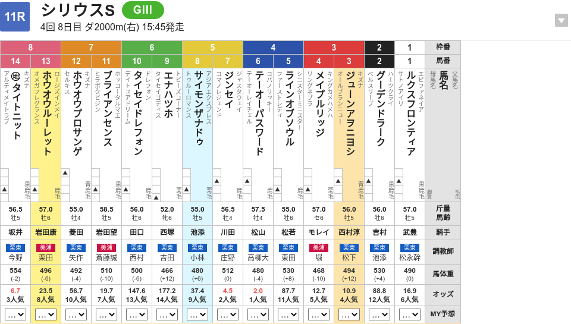

### 【スプリンターズステークス 2025/09/28(日) 】

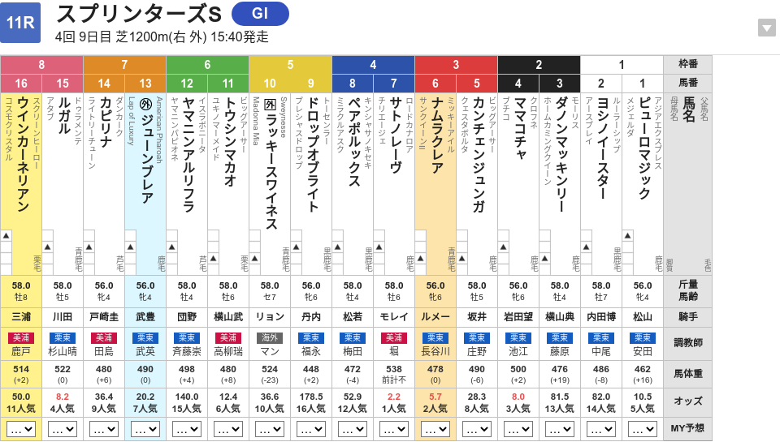

## 4. 単勝予測結果

### 【シリウスステークス(GⅢ) 2025/09/27(土)】

| 枠番 | 馬番 | 人気 | オッズ | 馬名 | 騎手 | 調教師 | 予測タイム(sec) | 1_順位 | 1-3着内確率(%) | 2_順位 | ﾀﾞｰｸﾎｰｽ確率(%) | 3_順位 |
| --- | --- | --- | --- | --- | --- | --- | --- | --- | --- | --- | --- | --- |
| 1 | 1 | 6 | 16.9 | ルクスフロンティア | 武豊 | 松永幹夫 | 134.2 | 12 | 15.6 | 4 | 0.9 | 11 |
| 2 | 2 | 12 | 88.8 | グーデンドラーク | 吉村誠之助 | 池添学 | 127.7 | 3 | 9.2 | 8 | 62.2 | 1 |
| 3 | 3 | 4 | 10.9 | ジューンアヲニヨシ | 西村淳也 | 松下武士 | 129.5 | 6 | 16.3 | 3 | 1.5 | 9 |
| 3 | 4 | 5 | 12.7 | メイプルリッジ | Ｊ．モレイラ | 堀宣行 | 131.6 | 9 | 13.6 | 7 | 0.9 | 10 |
| 4 | 5 | 11 | 87.7 | ラインオブソウル | 松若風馬 | 東田明士 | 134.5 | 13 | 2.3 | 12 | 13.0 | 6 |
| 4 | 6 | 1 | 2.0 | テーオーパスワード | 松山弘平 | 高柳大輔 | 121.5 | 1 | 24.3 | 1 | 0.5 | 14 |
| 5 | 7 | 2 | 4.5 | ジンセイ | 川田将雅 | 庄野靖志 | 130.7 | 7 | 15.1 | 5 | 0.5 | 13 |
| 5 | 8 | 9 | 37.4 | サイモンザナドゥ | 池添謙一 | 小林真也 | 135.0 | 14 | 2.2 | 13 | 13.5 | 5 |
| 6 | 9 | 14 | 177.2 | エナハツホ | 西塚洸二 | 吉田直弘 | 133.9 | 11 | 2.0 | 14 | 14.9 | 3 |
| 6 | 10 | 13 | 147.6 | タイセイドレフォン | 田口貫太 | 西村真幸 | 132.4 | 10 | 3.5 | 11 | 14.9 | 4 |

[output cut: 4 more lines]

### 【スプリンターズステークス(GⅠ) 2025/09/28(日)】

| 枠番 | 馬番 | 人気 | オッズ | 馬名 | 騎手 | 調教師 | 予測タイム(sec) | 1_順位 | 1-3着内確率(%) | 2_順位 | ﾀﾞｰｸﾎｰｽ確率(%) | 3_順位 |
| --- | --- | --- | --- | --- | --- | --- | --- | --- | --- | --- | --- | --- |
| 1 | 1 | 5 | 10.5 | ピューロマジック | 松山弘平 | 安田翔伍 | 73.8 | 9.0 | 30.9 | 3 | 1.9 | 15 |
| 1 | 2 | 14 | 82.0 | ヨシノイースター | 内田博幸 | 中尾秀正 | 75.3 | 13.0 | 5.2 | 15 | 48.1 | 5 |
| 2 | 3 | 13 | 81.5 | ダノンマッキンリー | 横山典弘 | 藤原英昭 | 68.2 | 4.0 | 12.5 | 12 | 68.3 | 2 |
| 2 | 4 | 3 | 8.0 | ママコチャ | 岩田望来 | 池江泰寿 | 67.9 | 3.0 | 40.9 | 2 | 3.0 | 12 |
| 3 | 5 | 8 | 28.3 | カンチェンジュンガ | 坂井瑠星 | 庄野靖志 | 74.8 | 11.0 | 8.0 | 13 | 3.7 | 11 |
| 3 | 6 | 2 | 5.7 | ナムラクレア | Ｃ．ルメール | 長谷川浩大 | 75.3 | 12.0 | 41.7 | 1 | 5.6 | 8 |
| 4 | 7 | 1 | 2.2 | サトノレーヴ | Ｊ．モレイラ | 堀宣行 | 66.7 | 1.5 | 21.1 | 5 | 3.9 | 10 |
| 4 | 8 | 12 | 52.9 | ペアポルックス | 松若風馬 | 梅田智之 | 73.4 | 7.0 | 12.6 | 11 | 62.0 | 3 |
| 5 | 9 | 16 | 178.5 | ドロップオブライト | 丹内祐次 | 福永祐一 | 75.9 | 15.0 | 7.3 | 14 | 26.6 | 6 |
| 6 | 11 | 6 | 12.4 | トウシンマカオ | 横山武史 | 高柳瑞樹 | 73.6 | 8.0 | 29.7 | 4 | 2.2 | 14 |

[output cut: 5 more lines]

## 5. 人気と着順の乖離率推移

### 【シリウスステークス_1997y_2019y】

[interactive chart not shown]

### 【スプリンターズステークス_1990y_2019y】

[interactive chart not shown]

### 【シリウスステークス_1997y_2019y】

| No | 開催年 | 不整合率(%) | 頭数 | 人気別着順(1-3位) | 人気別着順(全体) |
| --- | --- | --- | --- | --- | --- |
| 23 | 2019 | 55.2 | 14頭 | 6-7-5 | 6\|7\|5\|3\|10\|1\|13\|14\|2\|9\|11\|4\|8\|12 |
| 22 | 2018 | 45.4 | 16頭 | 2-7-3 | 2\|7\|3\|8\|12\|9\|14\|4\|6\|16\|1\|10\|13\|5\|11\|15 |
| 21 | 2017 | 48.0 | 16頭 | 11-5-3 | 11\|5\|3\|7\|10\|13\|1\|2\|6\|9\|4\|15\|8\|12\|16\|14 |
| 20 | 2016 | 13.5 | 11頭 | 1-2-4 | 1\|2\|4\|5\|6\|10\|11\|3\|9\|7\|8 |
| 19 | 2015 | 34.4 | 12頭 | 3-1-2 | 3\|1\|2\|12\|10\|8\|4\|6\|9\|11\|5\|7 |
| 18 | 2014 | 29.6 | 14頭 | 1-3-7 | 1\|3\|7\|5\|6\|8\|14\|13\|2\|4\|12\|9\|11\|10 |
| 17 | 2013 | 62.9 | 15頭 | 5-3-6 | 5\|3\|6\|2\|13\|7\|4\|8\|15\|9\|10\|14\|16\|12\|1 |
| 16 | 2012 | 37.6 | 16頭 | 2-3-1 | 2\|3\|1\|11\|10\|8\|9\|5\|4\|15\|7\|14\|13\|16\|12\|6 |
| 15 | 2011 | 49.1 | 12頭 | 5-4-2 | 5\|4\|2\|1\|9\|6\|10\|7\|12\|3\|11\|8 |
| 14 | 2010 | 34.3 | 12頭 | 1-4-9 | 1\|4\|9\|10\|3\|5\|2\|8\|11\|6\|7\|12 |

[output cut: 13 more lines]

### 【スプリンターズステークス_1990y_2019y】

| No | 開催年 | 不整合率(%) | 頭数 | 人気別着順(1-3位) | 人気別着順(全体) |
| --- | --- | --- | --- | --- | --- |
| 30 | 2019 | 37.9 | 16頭 | 2-3-1 | 2\|3\|1\|6\|9\|12\|13\|14\|5\|11\|10\|8\|4\|15\|16\|7 |
| 29 | 2018 | 35.5 | 15頭 | 1-11-13 | 1\|11\|13\|10\|4\|3\|2\|12\|15\|5\|16\|8\|7\|6\|14 |
| 28 | 2017 | 24.3 | 16頭 | 1-5-7 | 1\|5\|7\|16\|12\|8\|2\|9\|13\|14\|3\|6\|10\|11\|4\|15 |
| 27 | 2016 | 56.9 | 16頭 | 3-2-9 | 3\|2\|9\|5\|12\|8\|14\|16\|7\|11\|6\|1\|10\|15\|4\|13 |
| 26 | 2015 | 41.7 | 15頭 | 1-11-9 | 1\|11\|9\|4\|3\|6\|12\|15\|8\|7\|14\|5\|2\|10\|13 |
| 25 | 2014 | 54.9 | 18頭 | 13-2-5 | 13\|2\|5\|4\|10\|15\|9\|6\|14\|17\|7\|3\|1\|11\|16\|12\|8\|18 |
| 24 | 2013 | 18.9 | 16頭 | 1-2-15 | 1\|2\|15\|6\|10\|5\|3\|9\|13\|16\|4\|11\|8\|12\|14\|7 |
| 23 | 2012 | 23.2 | 16頭 | 2-1-9 | 2\|1\|9\|3\|8\|11\|13\|4\|15\|5\|12\|7\|16\|10\|14\|6 |
| 22 | 2011 | 46.5 | 15頭 | 3-9-7 | 3\|9\|7\|1\|4\|6\|5\|8\|13\|10\|2\|15\|14\|11\|12 |
| 21 | 2010 | 55.1 | 16頭 | 10-3-7 | 10\|3\|7\|6\|2\|8\|1\|13\|11\|4\|14\|15\|9\|5\|12\|16 |

[output cut: 20 more lines]

## 6. 1-3番人気馬の着順分類予測

### 【シリウスステークス】

| 分類 | 凡例 | 発生確率(%) | 当該レース | 当該レースランク | 直近1年間 |
| --- | --- | --- | --- | --- | --- |
| 8: 1,2,3番人気すべて着外 (8_darkhorse) | * \| * \| * | 17.6 | 0.70 | 0.70 | 0.35 |
| 1: 1番人気のみ (1_pop1) | 1 \| * \| * | 16.9 | 0.94 | 0.94 | 0.00 |
| 4: 1,2番人気のみ (4_pop12) | 1 \| 2 \| * | 16.4 | 0.92 | 0.92 | 0.00 |
| 5: 1,3番人気のみ (5_pop13) | 1 \| 3 \| * | 13.8 | 1.94 | 1.94 | 0.00 |
| 2: 2番人気のみ (2_pop2) | 2 \| * \| * | 9.6 | 2.67 | 2.67 | 0.00 |
| 6: 2,3番人気のみ (6_pop23) | 2 \| 3 \| * | 9.6 | 1.35 | 1.35 | 0.00 |
| 3: 3番人気のみ (3_pop3) | 3 \| * \| * | 9.2 | 0.64 | 0.64 | 0.00 |
| 7: 1,2,3番人気すべて着内 (7_pop123) | 1 \| 2 \| 3 | 6.9 | 0.97 | 0.97 | 0.14 |

### 【スプリンターズステークス】

| 分類 | 凡例 | 発生確率(%) | 当該レース | 当該レースランク | 直近1年間 |
| --- | --- | --- | --- | --- | --- |
| 8: 1,2,3番人気すべて着外 (8_darkhorse) | * \| * \| * | 17.6 | 3.09 | 3.09 | 0.00 |
| 1: 1番人気のみ (1_pop1) | 1 \| * \| * | 16.9 | 0.84 | 0.84 | 0.00 |
| 4: 1,2番人気のみ (4_pop12) | 1 \| 2 \| * | 16.4 | 0.82 | 0.82 | 0.00 |
| 5: 1,3番人気のみ (5_pop13) | 1 \| 3 \| * | 13.8 | 2.42 | 2.42 | 0.00 |
| 2: 2番人気のみ (2_pop2) | 2 \| * \| * | 9.6 | 1.12 | 1.12 | 0.00 |
| 6: 2,3番人気のみ (6_pop23) | 2 \| 3 \| * | 9.6 | 1.68 | 1.68 | 0.00 |
| 3: 3番人気のみ (3_pop3) | 3 \| * \| * | 9.2 | 1.61 | 1.61 | 0.00 |
| 7: 1,2,3番人気すべて着内 (7_pop123) | 1 \| 2 \| 3 | 6.9 | 0.24 | 0.24 | 0.07 |

## 7. 3連複予測結果

### 【シリウスステークス(GⅢ) 2025/09/27(土)】

| 分類 | 馬番 | 枠番 | 人気 | 平均予測タイム(sec) | 1-3着内確率(%) | ﾀﾞｰｸﾎｰｽ確率(%) | 馬名 | 騎手 | 調教師 |
| --- | --- | --- | --- | --- | --- | --- | --- | --- | --- |
| 5: 1,3番人気のみ (5_pop13) | 6-14-3 | 4-8-3 | 1-3-4 | 126.60 | 0.87 | 0.00 | テーオーパスワード \| タイトニット \| ジューンアヲニヨシ | 松山弘平 \| 坂井瑠星 \| 西村淳也 | 高柳大輔 \| 今野貞一 \| 松下武士 |
| 5: 1,3番人気のみ (5_pop13) | 6-14-1 | 4-8-1 | 1-3-6 | 128.17 | 0.83 | 0.00 | テーオーパスワード \| タイトニット \| ルクスフロンティア | 松山弘平 \| 坂井瑠星 \| 武豊 | 高柳大輔 \| 今野貞一 \| 松永幹夫 |
| 7: 1,2,3番人気すべて着内 (7_pop123) | 6-7-14 | 4-5-8 | 1-2-3 | 127.00 | 0.80 | 0.00 | テーオーパスワード \| ジンセイ \| タイトニット | 松山弘平 \| 川田将雅 \| 坂井瑠星 | 高柳大輔 \| 庄野靖志 \| 今野貞一 |
| 5: 1,3番人気のみ (5_pop13) | 6-14-11 | 4-8-7 | 1-3-7 | 126.13 | 0.74 | 0.00 | テーオーパスワード \| タイトニット \| ブライアンセンス | 松山弘平 \| 坂井瑠星 \| 岩田望来 | 高柳大輔 \| 今野貞一 \| 斎藤誠 |
| 5: 1,3番人気のみ (5_pop13) | 6-14-4 | 4-8-3 | 1-3-5 | 127.30 | 0.73 | 0.00 | テーオーパスワード \| タイトニット \| メイプルリッジ | 松山弘平 \| 坂井瑠星 \| Ｊ．モレイラ | 高柳大輔 \| 今野貞一 \| 堀宣行 |
| 1: 1番人気のみ (1_pop1) | 6-3-1 | 4-3-1 | 1-4-6 | 128.40 | 0.62 | 0.00 | テーオーパスワード \| ジューンアヲニヨシ \| ルクスフロンティア | 松山弘平 \| 西村淳也 \| 武豊 | 高柳大輔 \| 松下武士 \| 松永幹夫 |
| 4: 1,2番人気のみ (4_pop12) | 6-7-3 | 4-5-3 | 1-2-4 | 127.23 | 0.60 | 0.00 | テーオーパスワード \| ジンセイ \| ジューンアヲニヨシ | 松山弘平 \| 川田将雅 \| 西村淳也 | 高柳大輔 \| 庄野靖志 \| 松下武士 |
| 4: 1,2番人気のみ (4_pop12) | 6-7-1 | 4-5-1 | 1-2-6 | 128.80 | 0.57 | 0.00 | テーオーパスワード \| ジンセイ \| ルクスフロンティア | 松山弘平 \| 川田将雅 \| 武豊 | 高柳大輔 \| 庄野靖志 \| 松永幹夫 |
| 3: 3番人気のみ (3_pop3) | 14-3-1 | 8-3-1 | 3-4-6 | 130.83 | 0.56 | 0.00 | タイトニット \| ジューンアヲニヨシ \| ルクスフロンティア | 坂井瑠星 \| 西村淳也 \| 武豊 | 今野貞一 \| 松下武士 \| 松永幹夫 |
| 1: 1番人気のみ (1_pop1) | 6-3-11 | 4-3-7 | 1-4-7 | 126.37 | 0.54 | 0.00 | テーオーパスワード \| ジューンアヲニヨシ \| ブライアンセンス | 松山弘平 \| 西村淳也 \| 岩田望来 | 高柳大輔 \| 松下武士 \| 斎藤誠 |

[output cut: 354 more lines]

### 【スプリンターズステークス(GⅠ) 2025/09/28(日)】

| 分類 | 馬番 | 枠番 | 人気 | 平均予測タイム(sec) | 1-3着内確率(%) | ﾀﾞｰｸﾎｰｽ確率(%) | 馬名 | 騎手 | 調教師 |
| --- | --- | --- | --- | --- | --- | --- | --- | --- | --- |
| 6: 2,3番人気のみ (6_pop23) | 6-4-1 | 3-2-1 | 2-3-5 | 72.33 | 5.28 | 0.00 | ナムラクレア \| ママコチャ \| ピューロマジック | Ｃ．ルメール \| 岩田望来 \| 松山弘平 | 長谷川浩大 \| 池江泰寿 \| 安田翔伍 |
| 6: 2,3番人気のみ (6_pop23) | 6-4-11 | 3-2-6 | 2-3-6 | 72.27 | 5.07 | 0.00 | ナムラクレア \| ママコチャ \| トウシンマカオ | Ｃ．ルメール \| 岩田望来 \| 横山武史 | 長谷川浩大 \| 池江泰寿 \| 高柳瑞樹 |
| 2: 2番人気のみ (2_pop2) | 6-1-11 | 3-1-6 | 2-5-6 | 74.23 | 3.83 | 0.00 | ナムラクレア \| ピューロマジック \| トウシンマカオ | Ｃ．ルメール \| 松山弘平 \| 横山武史 | 長谷川浩大 \| 安田翔伍 \| 高柳瑞樹 |
| 3: 3番人気のみ (3_pop3) | 4-1-11 | 2-1-6 | 3-5-6 | 71.77 | 3.76 | 0.00 | ママコチャ \| ピューロマジック \| トウシンマカオ | 岩田望来 \| 松山弘平 \| 横山武史 | 池江泰寿 \| 安田翔伍 \| 高柳瑞樹 |
| 7: 1,2,3番人気すべて着内 (7_pop123) | 7-6-4 | 4-3-2 | 1-2-3 | 69.97 | 3.60 | 0.01 | サトノレーヴ \| ナムラクレア \| ママコチャ | Ｊ．モレイラ \| Ｃ．ルメール \| 岩田望来 | 堀宣行 \| 長谷川浩大 \| 池江泰寿 |
| 6: 2,3番人気のみ (6_pop23) | 6-4-14 | 3-2-7 | 2-3-9 | 71.27 | 3.03 | 0.09 | ナムラクレア \| ママコチャ \| カピリナ | Ｃ．ルメール \| 岩田望来 \| 戸崎圭太 | 長谷川浩大 \| 池江泰寿 \| 田島俊明 |
| 6: 2,3番人気のみ (6_pop23) | 6-4-15 | 3-2-8 | 2-3-4 | 72.47 | 2.94 | 0.00 | ナムラクレア \| ママコチャ \| ルガル | Ｃ．ルメール \| 岩田望来 \| 川田将雅 | 長谷川浩大 \| 池江泰寿 \| 杉山晴紀 |
| 6: 2,3番人気のみ (6_pop23) | 6-4-13 | 3-2-7 | 2-3-7 | 69.97 | 2.88 | 0.01 | ナムラクレア \| ママコチャ \| ジューンブレア | Ｃ．ルメール \| 岩田望来 \| 武豊 | 長谷川浩大 \| 池江泰寿 \| 武英智 |
| 4: 1,2番人気のみ (4_pop12) | 7-6-1 | 4-3-1 | 1-2-5 | 71.93 | 2.72 | 0.00 | サトノレーヴ \| ナムラクレア \| ピューロマジック | Ｊ．モレイラ \| Ｃ．ルメール \| 松山弘平 | 堀宣行 \| 長谷川浩大 \| 安田翔伍 |
| 5: 1,3番人気のみ (5_pop13) | 7-4-1 | 4-2-1 | 1-3-5 | 69.47 | 2.66 | 0.00 | サトノレーヴ \| ママコチャ \| ピューロマジック | Ｊ．モレイラ \| 岩田望来 \| 松山弘平 | 堀宣行 \| 池江泰寿 \| 安田翔伍 |

[output cut: 354 more lines]

## 8. 直近の全レース情報

| No | 日付 | 競馬場 | R | 発走 | レース名 | 距離 | 頭数 | URL(netkeiba) |
| --- | --- | --- | --- | --- | --- | --- | --- | --- |
| 1 | 2025/09/27(土) | 06_中山 | 9R | 14:15 | 芙蓉S | 2000 | 10頭 | https://race.netkeiba.com/race/shutuba.html?race_id=202506040809&amp;rf=race_list |
| 2 | 2025/09/27(土) | 06_中山 | 10R | 14:50 | 勝浦特別 | 1200 | 28頭 | https://race.netkeiba.com/race/shutuba.html?race_id=202506040810&amp;rf=race_list |
| 3 | 2025/09/27(土) | 06_中山 | 11R | 15:30 | 秋風S | 1600 | 18頭 | https://race.netkeiba.com/race/shutuba.html?race_id=202506040811&amp;rf=race_list |
| 4 | 2025/09/27(土) | 09_阪神 | 9R | 14:30 | ヤマボウシ賞 | 1400 | 8頭 | https://race.netkeiba.com/race/shutuba.html?race_id=202509040809&amp;rf=race_list |
| 5 | 2025/09/27(土) | 09_阪神 | 10R | 15:05 | 道頓堀S | 1200 | 24頭 | https://race.netkeiba.com/race/shutuba.html?race_id=202509040810&amp;rf=race_list |
| 6 | 2025/09/27(土) | 09_阪神 | 11R | 15:45 | シリウスステークス | 2000 | 17頭 | https://race.netkeiba.com/race/shutuba.html?race_id=202509040811&amp;rf=race_list |
| 7 | 2025/09/28(日) | 06_中山 | 9R | 14:25 | サフラン賞 | 1600 | 10頭 | https://race.netkeiba.com/race/shutuba.html?race_id=202506040909&amp;rf=race_list |
| 8 | 2025/09/28(日) | 06_中山 | 10R | 15:00 | 茨城新聞杯 | 2000 | 18頭 | https://race.netkeiba.com/race/shutuba.html?race_id=202506040910&amp;rf=race_list |
| 9 | 2025/09/28(日) | 06_中山 | 11R | 15:40 | スプリンターズステークス | 1200 | 17頭 | https://race.netkeiba.com/race/shutuba.html?race_id=202506040911&amp;rf=race_list |
| 10 | 2025/09/28(日) | 06_中山 | 12R | 16:30 | 外房S | 1200 | 28頭 | https://race.netkeiba.com/race/shutuba.html?race_id=202506040912&amp;rf=race_list |

[output cut: 3 more lines]